# Lab 8 - Logit and Probit Models

Sara Troshani

# Introduction

For this lab, I used the same couples data from Lab 7.

The outcome variable is `he_older_6`. It equals 1 when the husband is more than 6 years older than the wife.

I compared OLS, logit, and probit models. I also looked at different cutoffs, age groups, and false positive and false negative errors.

# OLS, Logit, and Probit

Model Accuracy Comparison

| Model | Accuracy |
| --- | --- |
| OLS | 54.1% |
| Logit | 57.1% |
| Probit | 56.2% |

The logit model had the highest accuracy at about 57.1%.

Probit was close at 56.2%, and OLS had the lowest accuracy at 54.1%.

The models also made different types of mistakes. OLS had more false positives, while logit had more false negatives.

# Cutoff Comparison

The average predicted probability was about 0.146 for both logit and probit.

When I used a cutoff of 0.5, both models predicted every observation as 0.

This means that 0.5 was too high for this outcome.

Using the average predicted probability worked better for this comparison.

# Accuracy by Age Group

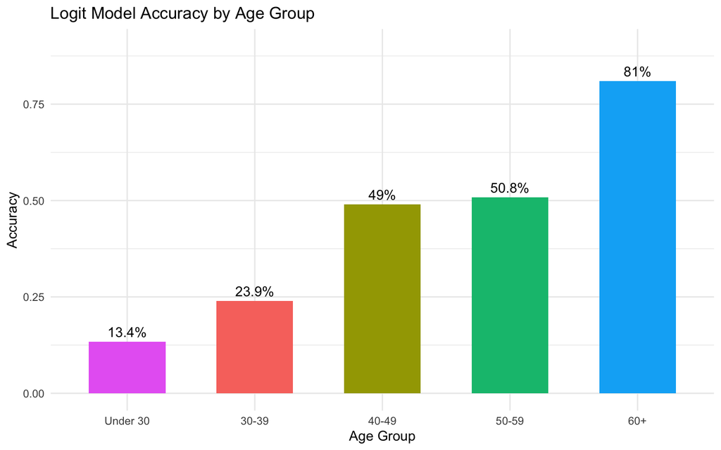

The model worked very differently across age groups.

Accuracy was very low for younger couples and much higher for older couples.

For people under 30, accuracy was about 13.4%.

For the 60+ group, accuracy was about 81%.

This shows that the model had more trouble predicting younger couples.

# Adding Age Squared

Because the results were very different by age, I added Age Squared to see if it would improve the model.

Age and Age Squared were both statistically significant.

The original logit model had about 57.1% accuracy.

The Age Squared model had about 51.4% accuracy.

The Age Squared model had lower residual deviance and AIC, which means it fit the data better overall. But its prediction accuracy was lower.

Comparison of Logit Models

| Model | Accuracy | False Positives | False Negatives |
| --- | --- | --- | --- |
| Original Logit | 57.1% | 132767 | 24423 |
| Logit + Age Squared | 51.4% | 160401 | 17653 |

# False Positive vs False Negative Tradeoff

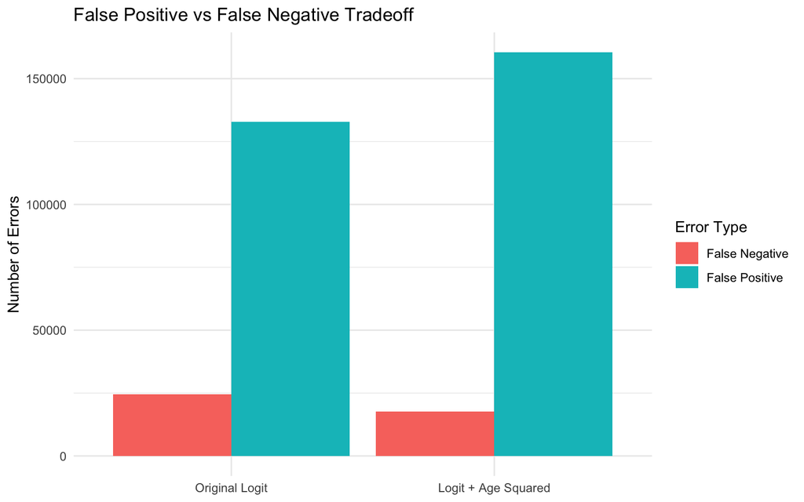

Adding Age Squared lowered false negatives from 24,423 to 17,653.

But false positives increased from 132,767 to 160,401.

So the new model found more positive cases, but it also made more false positive mistakes.

# Conclusion

The logit model had the highest accuracy out of OLS, logit, and probit.

The cutoff also made a difference. A cutoff of 0.5 did not work well for this outcome.

The model performed much worse for younger couples than older couples.

Adding Age Squared improved the model fit, but it did not improve prediction accuracy.

Overall, it is important to look at more than just accuracy when comparing models.